# Red Wine Quality

Nermin Elgrawany

January 14, 2019

### Explore the data:

##### Load the dataset and packages

##### Names of dataframe variables:

```
##  [1] "X"                    "fixed.acidity"        "volatile.acidity"
##  [4] "citric.acid"          "residual.sugar"       "chlorides"
##  [7] "free.sulfur.dioxide"  "total.sulfur.dioxide" "density"
## [10] "pH"                   "sulphates"            "alcohol"
## [13] "quality"
```

##### The dimenssions of the dataframe:

```
## [1] 1599   13
```

##### Datatype of the dataframe:

```
## 'data.frame':    1599 obs. of  13 variables:
##  $ X                   : int  1 2 3 4 5 6 7 8 9 10 ...
##  $ fixed.acidity       : num  7.4 7.8 7.8 11.2 7.4 7.4 7.9 7.3 7.8 7.5 ...
##  $ volatile.acidity    : num  0.7 0.88 0.76 0.28 0.7 0.66 0.6 0.65 0.58 0.5 ...
##  $ citric.acid         : num  0 0 0.04 0.56 0 0 0.06 0 0.02 0.36 ...
##  $ residual.sugar      : num  1.9 2.6 2.3 1.9 1.9 1.8 1.6 1.2 2 6.1 ...
##  $ chlorides           : num  0.076 0.098 0.092 0.075 0.076 0.075 0.069 0.065 0.073 0.071 ...
##  $ free.sulfur.dioxide : num  11 25 15 17 11 13 15 15 9 17 ...
##  $ total.sulfur.dioxide: num  34 67 54 60 34 40 59 21 18 102 ...
##  $ density             : num  0.998 0.997 0.997 0.998 0.998 ...
##  $ pH                  : num  3.51 3.2 3.26 3.16 3.51 3.51 3.3 3.39 3.36 3.35 ...
##  $ sulphates           : num  0.56 0.68 0.65 0.58 0.56 0.56 0.46 0.47 0.57 0.8 ...
##  $ alcohol             : num  9.4 9.8 9.8 9.8 9.4 9.4 9.4 10 9.5 10.5 ...
##  $ quality             : int  5 5 5 6 5 5 5 7 7 5 ...
```

##### Statistical Summary of the dataframe:

```
##        X          fixed.acidity   volatile.acidity  citric.acid
##  Min.   :   1.0   Min.   : 4.60   Min.   :0.1200   Min.   :0.000
##  1st Qu.: 400.5   1st Qu.: 7.10   1st Qu.:0.3900   1st Qu.:0.090
##  Median : 800.0   Median : 7.90   Median :0.5200   Median :0.260
##  Mean   : 800.0   Mean   : 8.32   Mean   :0.5278   Mean   :0.271
##  3rd Qu.:1199.5   3rd Qu.: 9.20   3rd Qu.:0.6400   3rd Qu.:0.420
##  Max.   :1599.0   Max.   :15.90   Max.   :1.5800   Max.   :1.000
##  residual.sugar     chlorides       free.sulfur.dioxide
##  Min.   : 0.900   Min.   :0.01200   Min.   : 1.00
##  1st Qu.: 1.900   1st Qu.:0.07000   1st Qu.: 7.00
##  Median : 2.200   Median :0.07900   Median :14.00
##  Mean   : 2.539   Mean   :0.08747   Mean   :15.87
##  3rd Qu.: 2.600   3rd Qu.:0.09000   3rd Qu.:21.00
##  Max.   :15.500   Max.   :0.61100   Max.   :72.00
##  total.sulfur.dioxide    density             pH          sulphates
##  Min.   :  6.00       Min.   :0.9901   Min.   :2.740   Min.   :0.3300
##  1st Qu.: 22.00       1st Qu.:0.9956   1st Qu.:3.210   1st Qu.:0.5500
##  Median : 38.00       Median :0.9968   Median :3.310   Median :0.6200
##  Mean   : 46.47       Mean   :0.9967   Mean   :3.311   Mean   :0.6581
##  3rd Qu.: 62.00       3rd Qu.:0.9978   3rd Qu.:3.400   3rd Qu.:0.7300
##  Max.   :289.00       Max.   :1.0037   Max.   :4.010   Max.   :2.0000
##     alcohol         quality
##  Min.   : 8.40   Min.   :3.000
##  1st Qu.: 9.50   1st Qu.:5.000
##  Median :10.20   Median :6.000
##  Mean   :10.42   Mean   :5.636
##  3rd Qu.:11.10   3rd Qu.:6.000
##  Max.   :14.90   Max.   :8.000
```

##### Subset the dataframe to execlude the X variable

#### Dataframe in plots:

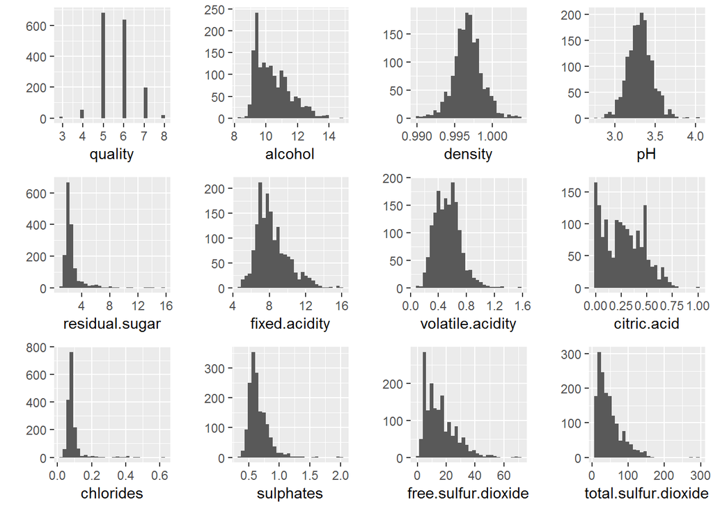

From the plots above, the histograms shows the distribution of the data. The distribution of the dataframe varied from normal distribution to right-skewed.

## Univariate Plot Section:

#### Explore each variable of the dataframe

#### Quality:

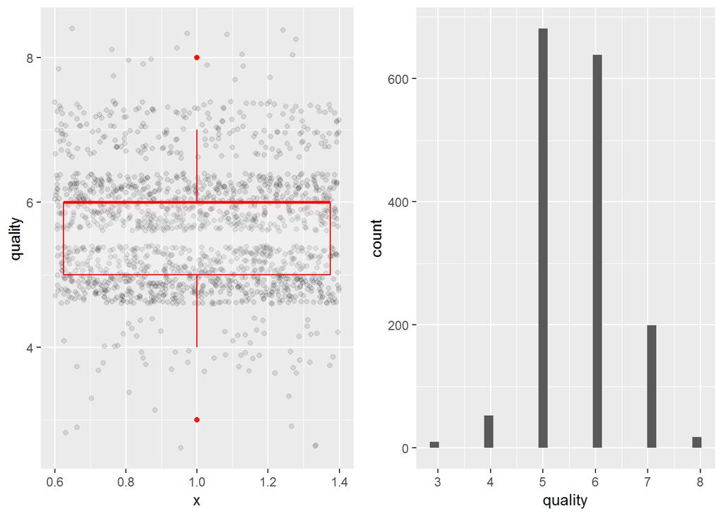

Statistical Summary of Quality:

```
##    Min. 1st Qu.  Median    Mean 3rd Qu.    Max.
##   3.000   5.000   6.000   5.636   6.000   8.000
```

#### Alcohol:

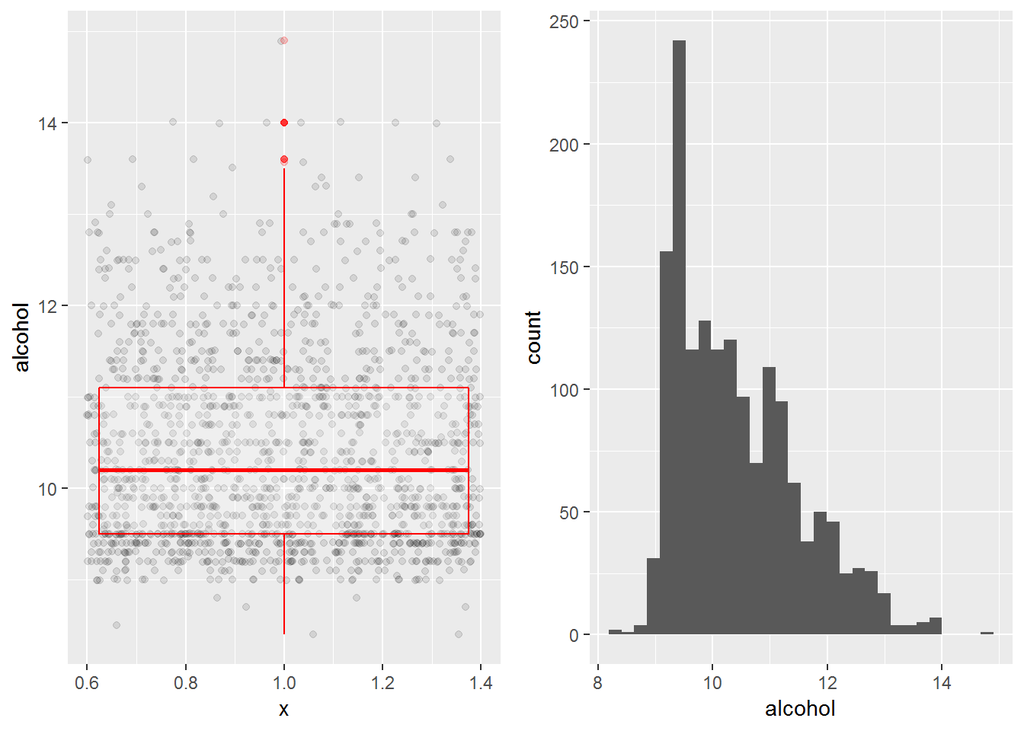

Statistical Summary of Alcohol:

```
##    Min. 1st Qu.  Median    Mean 3rd Qu.    Max.
##    8.40    9.50   10.20   10.42   11.10   14.90
```

The histogram shows the distribution of Alcohol, which appears to be right-skewed with highest peak of the distribution in the first quartile (approx. at 9.5). The boxplot depict the outliers, where there are outliers detected above the whisker of the boxplot (above 14).

#### Density:

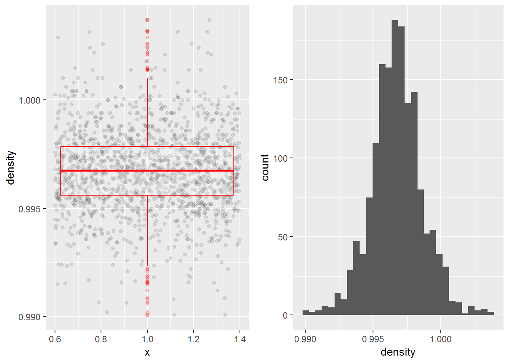

Statistical Summary of Density:

```
##    Min. 1st Qu.  Median    Mean 3rd Qu.    Max.
##  0.9901  0.9956  0.9968  0.9967  0.9978  1.0037
```

#### PH:

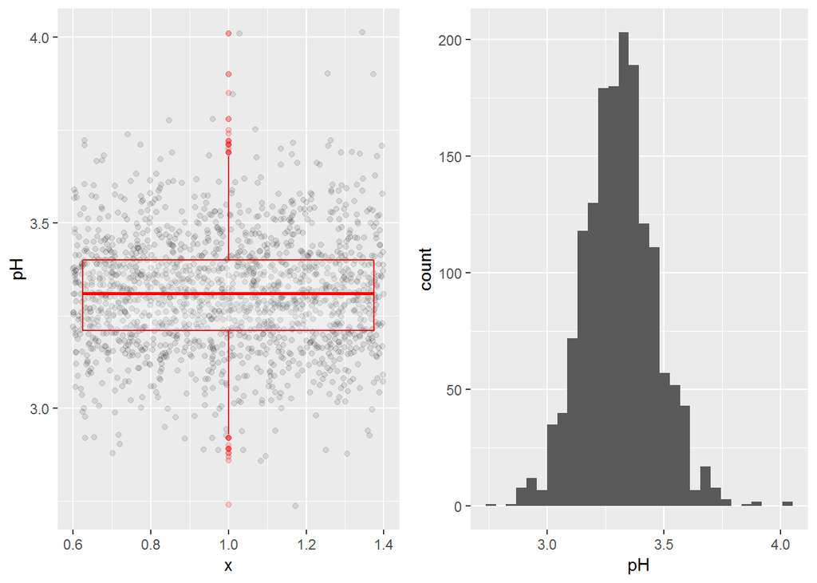

Statistical Summary of PH:

```
##    Min. 1st Qu.  Median    Mean 3rd Qu.    Max.
##   2.740   3.210   3.310   3.311   3.400   4.010
```

#### Residual Sugar:

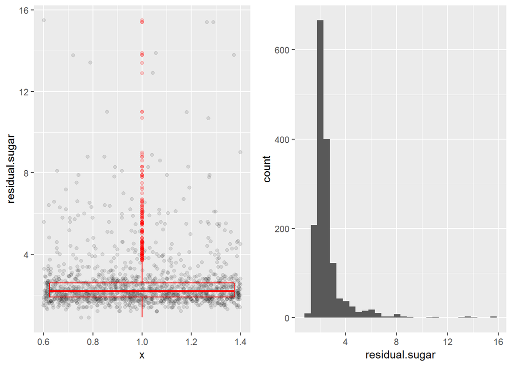

Statistical Summary of Residual Sugar:

```
##    Min. 1st Qu.  Median    Mean 3rd Qu.    Max.
##   0.900   1.900   2.200   2.539   2.600  15.500
```

#### Fixed Acidity:

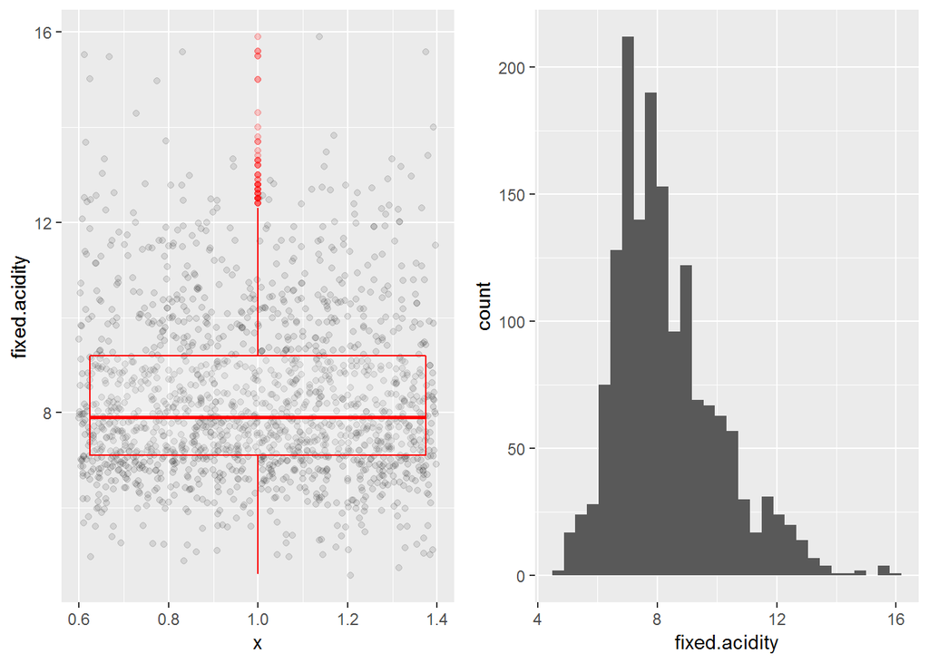

Statistical Summary of Fixed Acidity:

```
##    Min. 1st Qu.  Median    Mean 3rd Qu.    Max.
##    4.60    7.10    7.90    8.32    9.20   15.90
```

#### Volatile Acidity:

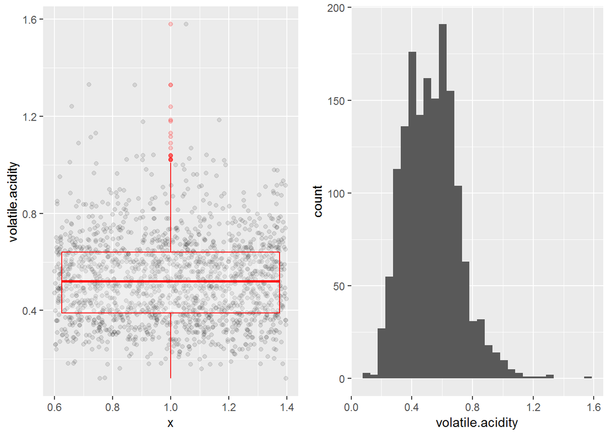

Statistical Summary of Volatile Acidity:

```
##    Min. 1st Qu.  Median    Mean 3rd Qu.    Max.
##  0.1200  0.3900  0.5200  0.5278  0.6400  1.5800
```

The distribution of volatile acidity is non-symmetric and bimodal with two peaks at 0.4 and 0.6. The median value is 0.52. Most observations fall in the range between 0.39 - 0.64 and outliers on the higher end of the scale are visible.

#### Citric Acid:

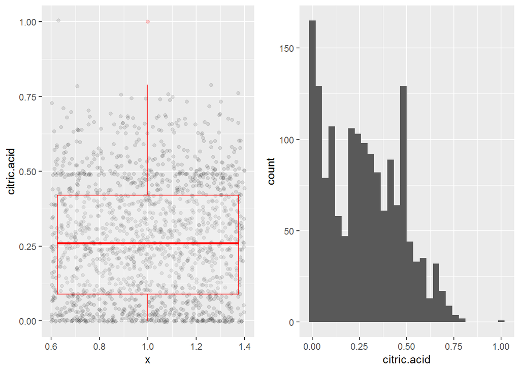

Statistical Summary of Citric Acid:

```
##    Min. 1st Qu.  Median    Mean 3rd Qu.    Max.
##   0.000   0.090   0.260   0.271   0.420   1.000
```

The distribution of Citric Acid is right-skewed with some ups and downs. We can see peaks at 0.25 and 0.50 which may hint at some bimodal behavior. A single value appears far away (approx. at 1.00) in the boxplot, which may depict an outlier.

#### Chlorides:

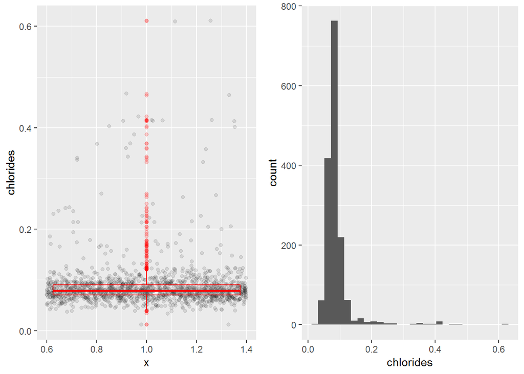

Statistical Summary of Chlorides:

```
##    Min. 1st Qu.  Median    Mean 3rd Qu.    Max.
## 0.01200 0.07000 0.07900 0.08747 0.09000 0.61100
```

The distribution of Chlorides looks right-skewed with discrete long right tail, and the extremes values clearly appears above and under the whisker in the boxplot.

#### Sulphates:

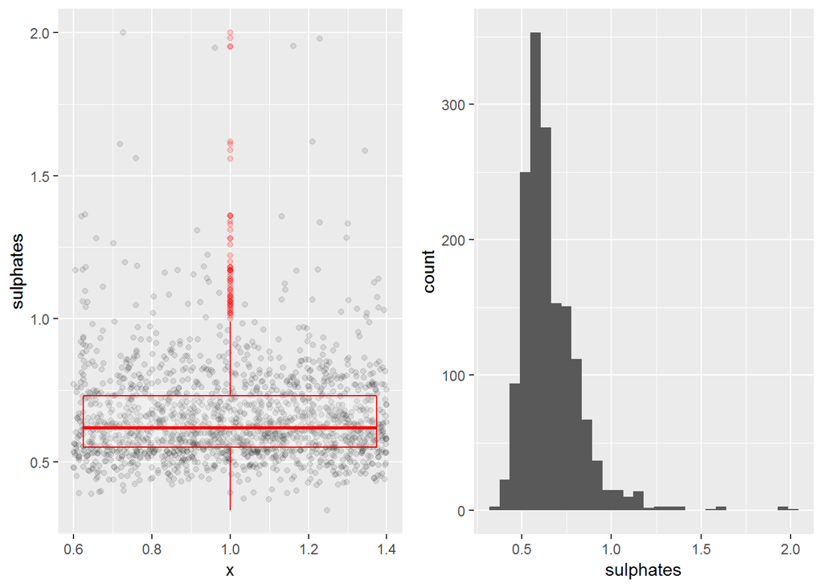

Statistical Summary of Sulphates:

```
##    Min. 1st Qu.  Median    Mean 3rd Qu.    Max.
##  0.3300  0.5500  0.6200  0.6581  0.7300  2.0000
```

The distribution of Sulphates is right-skewed, with a long tail of discrete outliers, which is also clearly obvious in the boxplot. Most of Sulphates values is between 0.55 and 0.73.

#### Free Sulfur Dioxide:

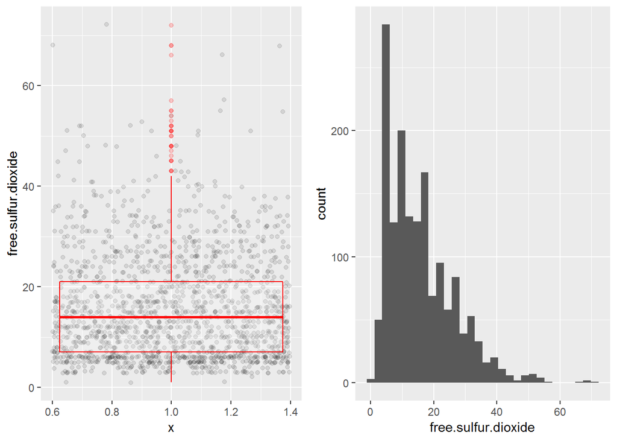

Statistical Summary of Free Sulfur Dioxide:

```
##    Min. 1st Qu.  Median    Mean 3rd Qu.    Max.
##    1.00    7.00   14.00   15.87   21.00   72.00
```

The distribution of Free Sulfur Dioxide is right-skewed. The right tail extends until a maximum of 72 with a gap between 57 and 66.

#### Total Sulfur Dioxide:

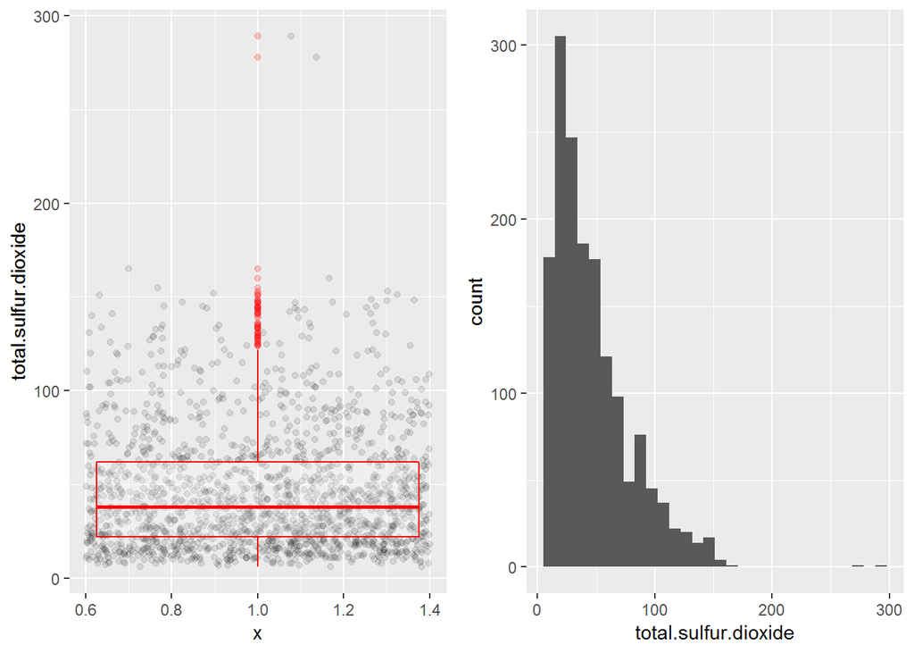

Statistical Summary of Total Sulfur Dioxide:

```
##    Min. 1st Qu.  Median    Mean 3rd Qu.    Max.
##    6.00   22.00   38.00   46.47   62.00  289.00
```

The distribution of Total Sulfur Dioxide is right-skewed with a median value of 38. On the right tail and the boxplot we can see a gap between 165 and 278 with only two values approx. greater than 278 which considered outliers.

### Univariate Plot Section Analysis:

#### What is the structure of your dataset?

There are 1599 obsevations of 12 variables in the data set, after execluding one variable (X variable).

#### What is/are the main feature(s) of interest in your dataset?

Quality of the red wine is the main feature in the dataset and will try to investigate how other variables would influence the quality of the wine.

#### What other features in the dataset do you think will help support your into your feature(s) of interest?

All Variables seems to be intersting features, such as Alcohol, Sugar Residual, Density and PH.

#### Did you create any new variables from existing variables in the dataset?

No, except execluding the X variable, because it just the index.

#### Of the features you investigated, were there any unusual distributions? you perform any operations on the data to tidy, adjust, or change the form the data? If so, why did you do this?

There were unusual distributions such as fixed.acidity, volatile.acidity, total.sulfur.dioxide, and sulphates seem to be long-tailed. I performed adjustment to the binwidth of Quality histogram as well as adding titles for the plots and x axis and y axis to look tidy.

## Bivariate Plot Section:

Let’s find some correlation between Quality and the other Features.

#### Quality cor. Alcohol:

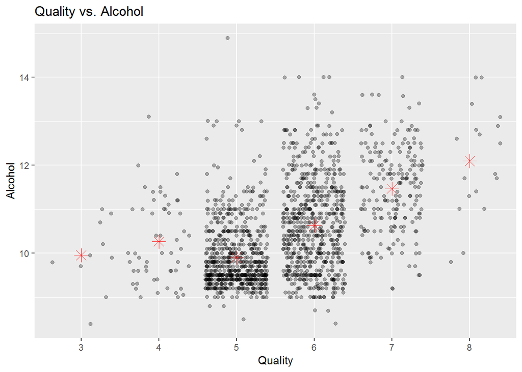

```
##
##  Pearson's product-moment correlation
##
## data:  rwq2$quality and rwq2$alcohol
## t = 21.639, df = 1597, p-value < 2.2e-16
## alternative hypothesis: true correlation is not equal to 0
## 95 percent confidence interval:
##  0.4373540 0.5132081
## sample estimates:
##       cor
## 0.4761663
```

#### Quality cor. Density:

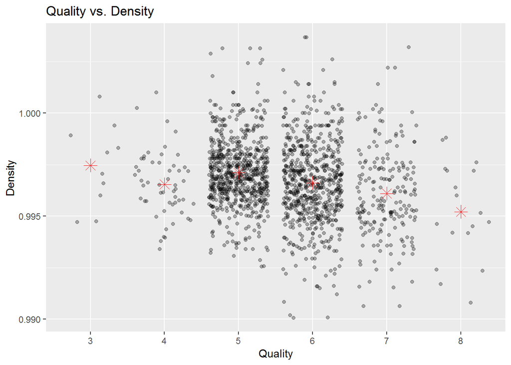

The correlation between Quality and Density is negative, which means that the higher Quality related to lower Density. The coefficient is -0.1749192

```
##
##  Pearson's product-moment correlation
##
## data:  rwq$quality and rwq$density
## t = -7.0997, df = 1597, p-value = 1.875e-12
## alternative hypothesis: true correlation is not equal to 0
## 95 percent confidence interval:
##  -0.2220365 -0.1269870
## sample estimates:
##        cor
## -0.1749192
```

#### Quality cor. pH:

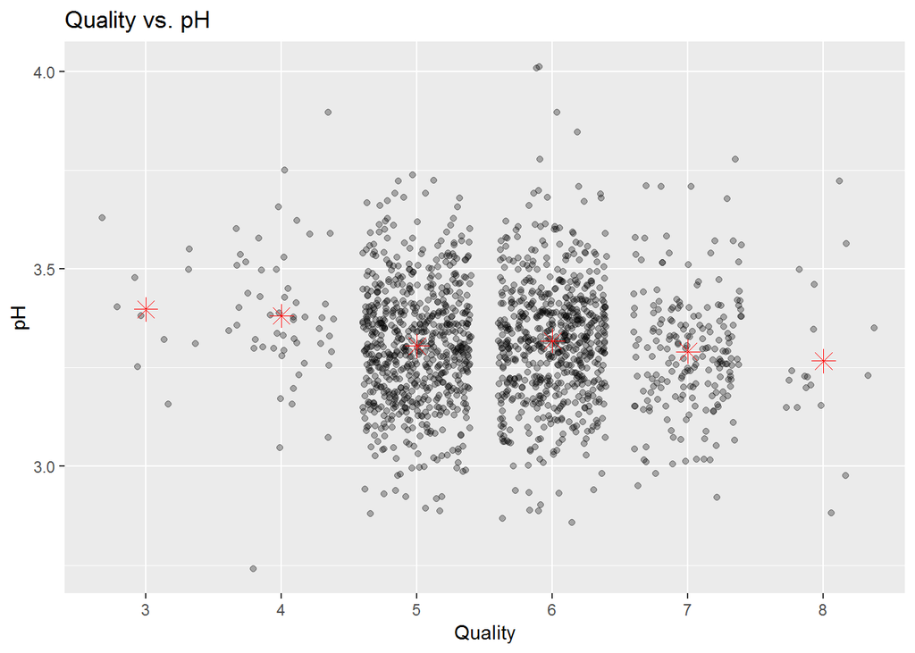

The correlation between Quality and pH is negative, but it seems like there is no relationship as the coefficient is -0.05773139.

```
##
##  Pearson's product-moment correlation
##
## data:  rwq$quality and rwq$pH
## t = -2.3109, df = 1597, p-value = 0.02096
## alternative hypothesis: true correlation is not equal to 0
## 95 percent confidence interval:
##  -0.106451268 -0.008734972
## sample estimates:
##         cor
## -0.05773139
```

#### Quality cor. Residual Sugar:

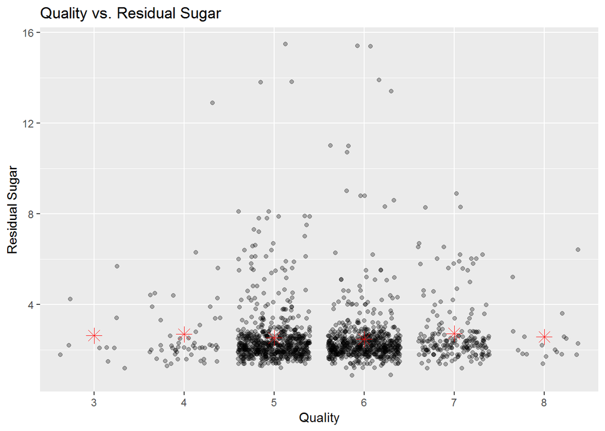

The correlation between Quality and Residual Sugar is positive, but it seems like there is no relationship as the coefficient is 0.01373164.

```
##
##  Pearson's product-moment correlation
##
## data:  rwq2$quality and rwq2$residual.sugar
## t = 0.5488, df = 1597, p-value = 0.5832
## alternative hypothesis: true correlation is not equal to 0
## 95 percent confidence interval:
##  -0.03531327  0.06271056
## sample estimates:
##        cor
## 0.01373164
```

#### Quality cor. Fixed Acidity:

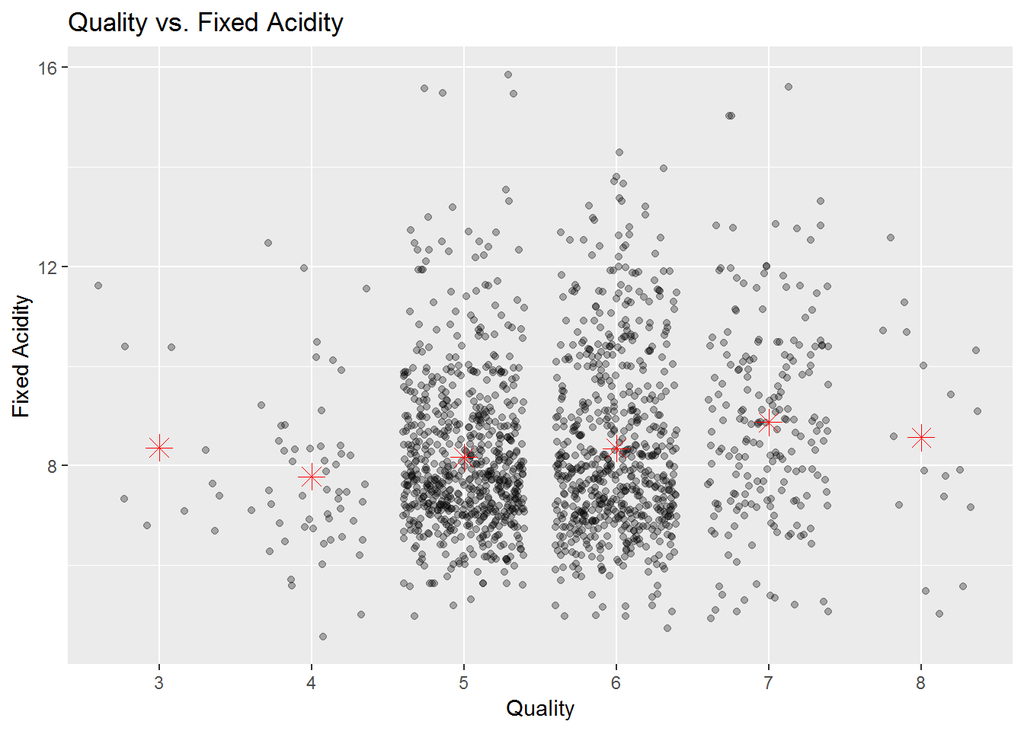

The correlation between Quality and Fixed Acidity is positive, but it seems like the relationship not obvious as the coefficient is not sufficiently high 0.1240516.

```
##
##  Pearson's product-moment correlation
##
## data:  rwq2$quality and rwq2$fixed.acidity
## t = 4.996, df = 1597, p-value = 6.496e-07
## alternative hypothesis: true correlation is not equal to 0
## 95 percent confidence interval:
##  0.07548957 0.17202667
## sample estimates:
##       cor
## 0.1240516
```

#### Quality cor. Vlatile Acidity:

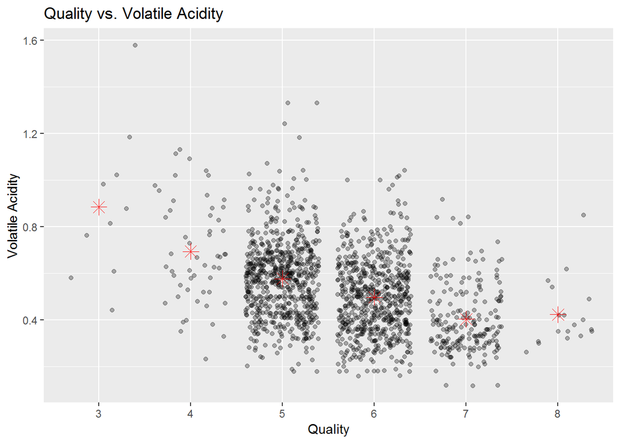

The correlation between Quality and Volatile Acidity is strong negative, as the coefficient is -0.3905578, that means the higher quality has lower volatile acidity.

```
##
##  Pearson's product-moment correlation
##
## data:  rwq2$quality and rwq2$volatile.acidity
## t = -16.954, df = 1597, p-value < 2.2e-16
## alternative hypothesis: true correlation is not equal to 0
## 95 percent confidence interval:
##  -0.4313210 -0.3482032
## sample estimates:
##        cor
## -0.3905578
```

#### Quality cor. Citric Acid:

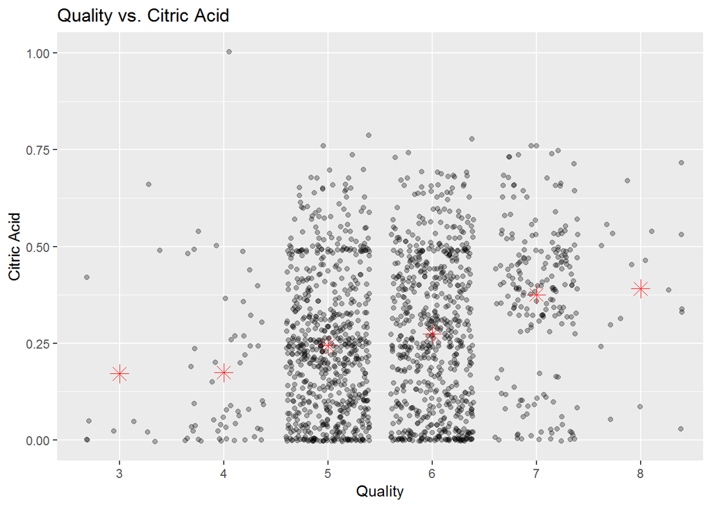

The correlation between Quality and Citric Acid is positive, and the coefficient is 0.2263725.

```
##
##  Pearson's product-moment correlation
##
## data:  rwq2$quality and rwq2$citric.acid
## t = 9.2875, df = 1597, p-value < 2.2e-16
## alternative hypothesis: true correlation is not equal to 0
## 95 percent confidence interval:
##  0.1793415 0.2723711
## sample estimates:
##       cor
## 0.2263725
```

#### Quality cor. Chlorides:

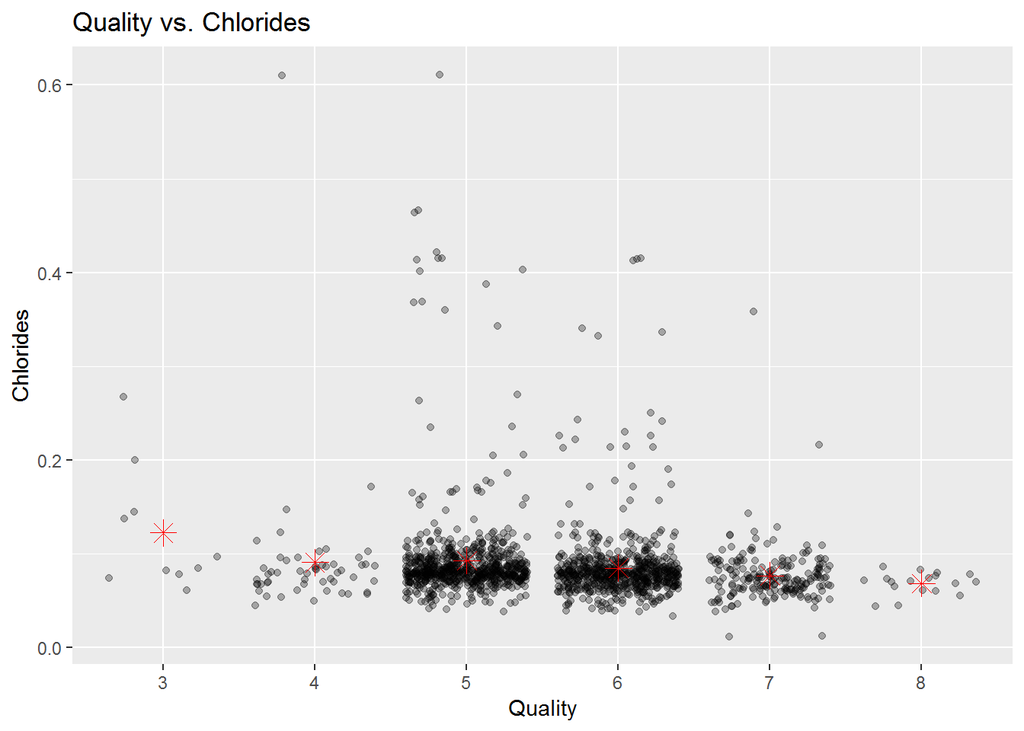

The correlation between Quality and Chlorides is negative, but it seems like the relationship not obvious as the coefficient is -0.1289066.

```
##
##  Pearson's product-moment correlation
##
## data:  rwq2$quality and rwq2$chlorides
## t = -5.1948, df = 1597, p-value = 2.313e-07
## alternative hypothesis: true correlation is not equal to 0
## 95 percent confidence interval:
##  -0.17681041 -0.08039344
## sample estimates:
##        cor
## -0.1289066
```

#### Quality cor. Sulphates:

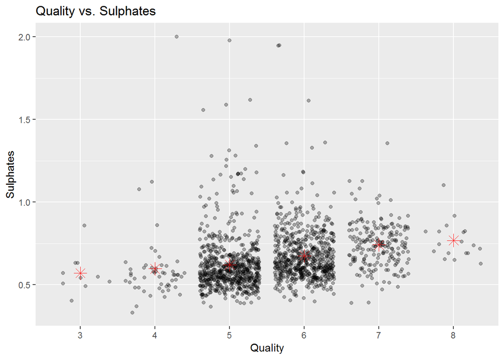

The correlation between Quality and Sulphates is positive, as the coefficient is 0.2513971.

```
##
##  Pearson's product-moment correlation
##
## data:  rwq2$quality and rwq2$sulphates
## t = 10.38, df = 1597, p-value < 2.2e-16
## alternative hypothesis: true correlation is not equal to 0
## 95 percent confidence interval:
##  0.2049011 0.2967610
## sample estimates:
##       cor
## 0.2513971
```

#### Quality cor. Free Sulfur Dioxide:

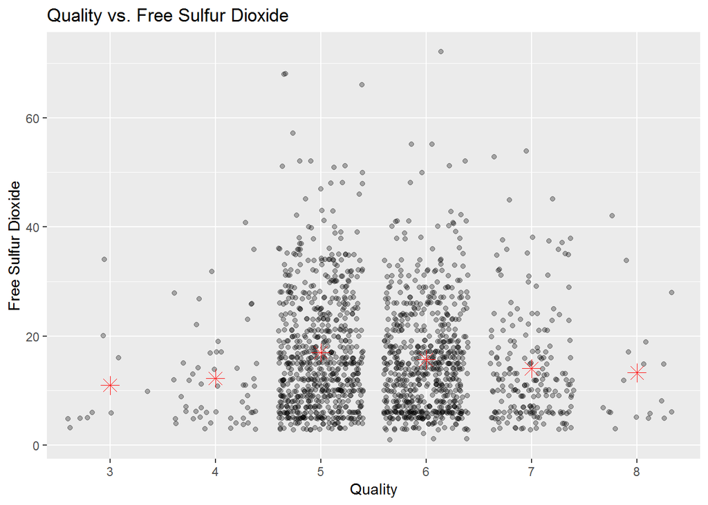

The correlation between Quality and Free Sulfur Dioxide is negative, as the coefficient is -0.05065606.

```
##
##  Pearson's product-moment correlation
##
## data:  rwq2$quality and rwq2$free.sulfur.dioxide
## t = -2.0269, df = 1597, p-value = 0.04283
## alternative hypothesis: true correlation is not equal to 0
## 95 percent confidence interval:
##  -0.099430290 -0.001638987
## sample estimates:
##         cor
## -0.05065606
```

#### Quality cor. Total Sulfur Dioxide:

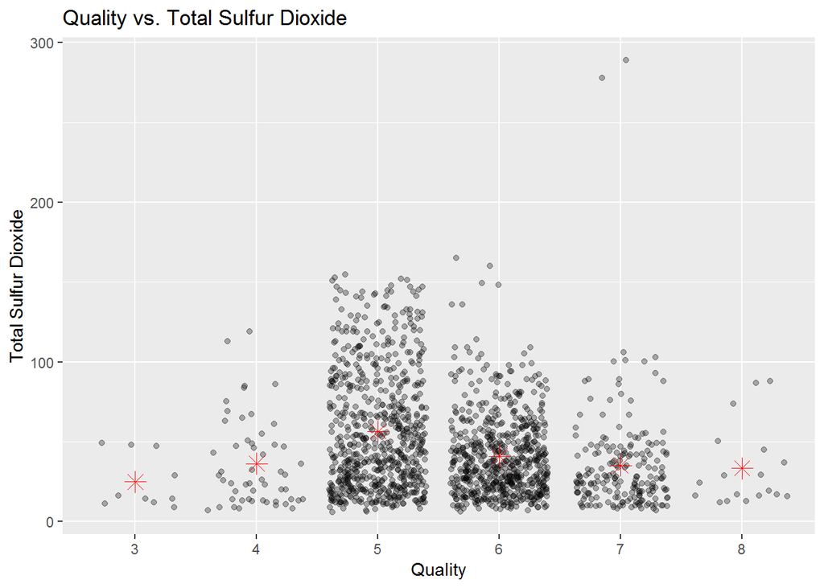

The correlation between Quality and total Sulfur Dioxide is negative, as the coefficient is -0.1851003.

```
##
##  Pearson's product-moment correlation
##
## data:  rwq2$quality and rwq2$total.sulfur.dioxide
## t = -7.5271, df = 1597, p-value = 8.622e-14
## alternative hypothesis: true correlation is not equal to 0
## 95 percent confidence interval:
##  -0.2320162 -0.1373252
## sample estimates:
##        cor
## -0.1851003
```

### Plots of other features (not the main feature):

#### Alcohol cor. Acidity

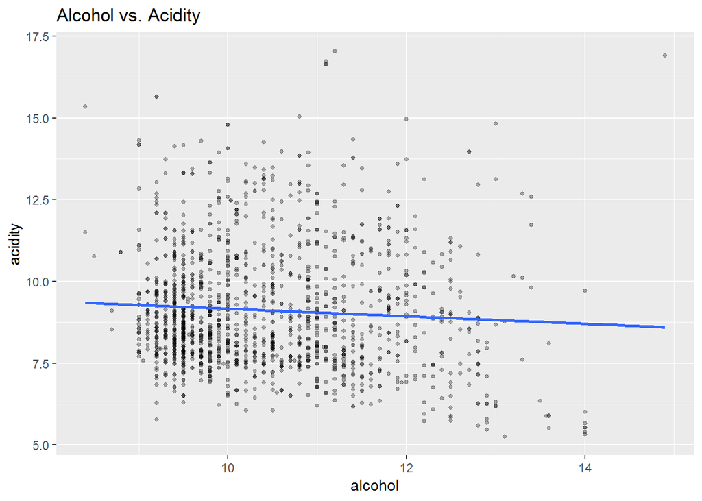

```
##
##  Pearson's product-moment correlation
##
## data:  rwq2$alcohol and rwq2$acidity
## t = -2.6702, df = 1597, p-value = 0.007659
## alternative hypothesis: true correlation is not equal to 0
## 95 percent confidence interval:
##  -0.11531215 -0.01770458
## sample estimates:
##         cor
## -0.06666786
```

#### pH cor. Free Sulfur Dioxide:

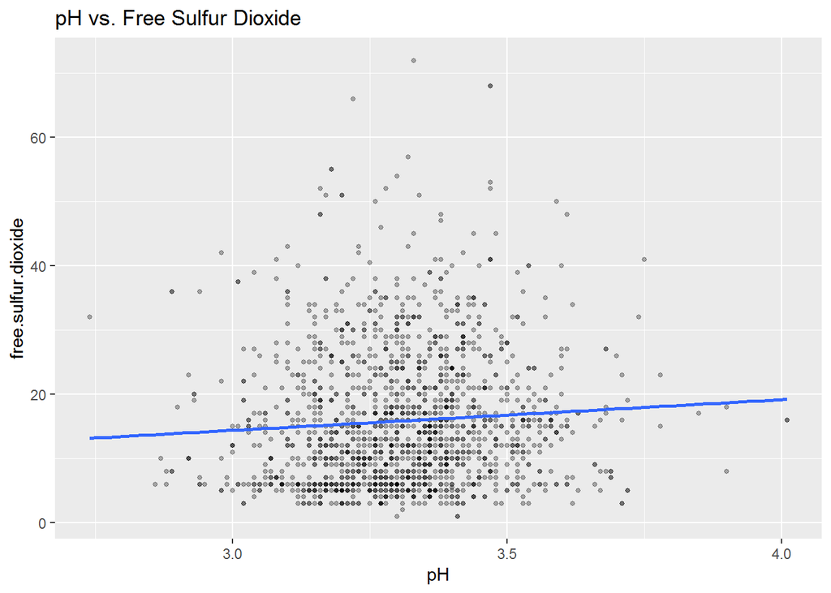

```
##
##  Pearson's product-moment correlation
##
## data:  rwq2$pH and rwq2$free.sulfur.dioxide
## t = 2.8195, df = 1597, p-value = 0.00487
## alternative hypothesis: true correlation is not equal to 0
## 95 percent confidence interval:
##  0.02143029 0.11898813
## sample estimates:
##       cor
## 0.0703775
```

#### Density cor. Residual Sugar:

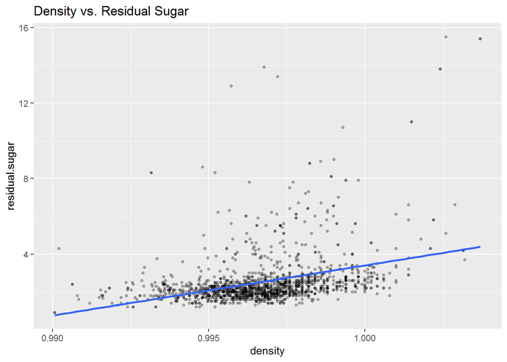

Correlation Coefficient between Density and Residual Sugar:

```
##
##  Pearson's product-moment correlation
##
## data:  rwq2$density and rwq2$residual.sugar
## t = 15.189, df = 1597, p-value < 2.2e-16
## alternative hypothesis: true correlation is not equal to 0
## 95 percent confidence interval:
##  0.3116908 0.3973835
## sample estimates:
##       cor
## 0.3552834
```

### Bivariate Plot Section Analysis:

#### Did you observe any interesting relationships between the other features (not the main feature(s) of interest)?

The correlation between the other features appeared as follow: Alcohol vs. Acidity = -0.06666786 , PH vs. Free.Sulfur.Dioxide = 0.0703775 , Density vs. Residual.Sugar = 0.3552834

#### What was the strongest relationship you found?

The strongest relationship found between Quality and Alcohol.

## Multivariate Plot Section:

#### Quality vs. Citric Acid and Sulphates

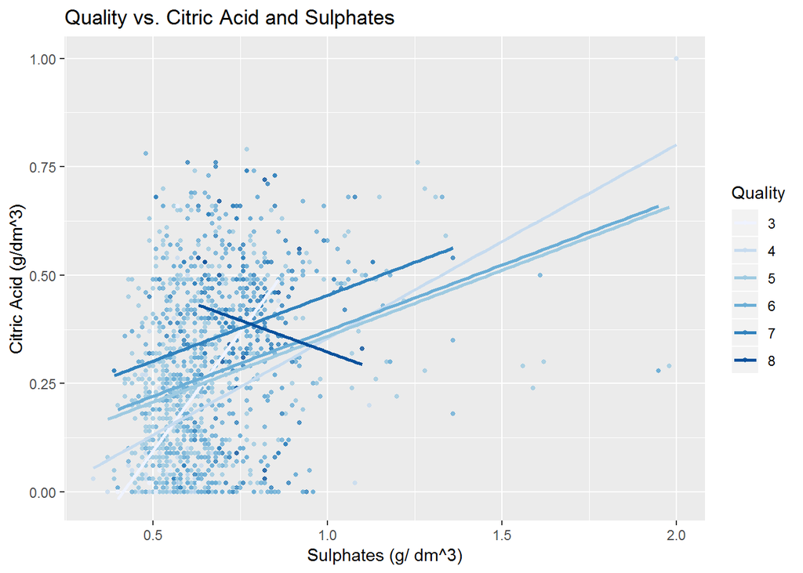

The graph represents the features influenced in the red wine quality, which are Sulphates and Citric Acid. It shows that the quality increases when Ctric Acid and Sulphates increase. As the influence appeared clearly in the range between (0.25 to .70 g/dm^3) of Citric Acid and (0.5 to 0.9 g/dm^3) of Sulphates.

#### Quality vs. Alcohol and Statistical Summary

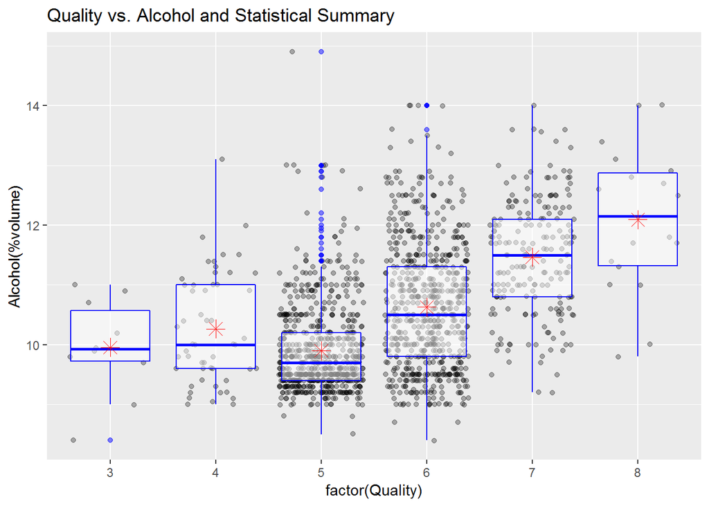

#### Quality vs. Volatile Acidity and Total Sulfur Dioxide

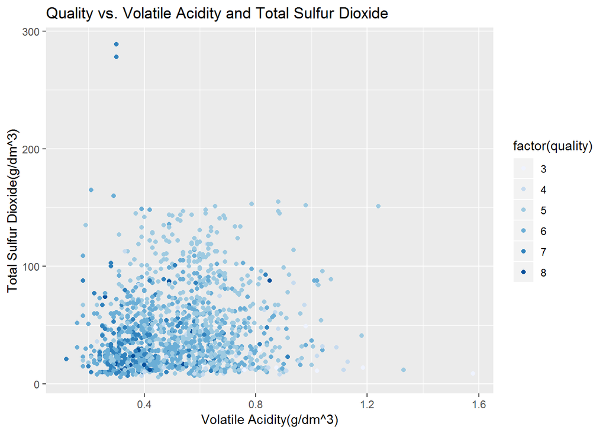

The graph represents the features influenced in the red wine quality, which are Volatile Acidity and Total Sulfur Dioxide. It shows that the quality decreases when Volatile Acidity and Total Sulfur Dioxide increase. As most of the high quality lay on the range of (100 g/dm^3) in Total Sulfur Dioxide and (0.5 g/dm^3) of Volatile Acidity

#### Quality vs. pH and Chlorides

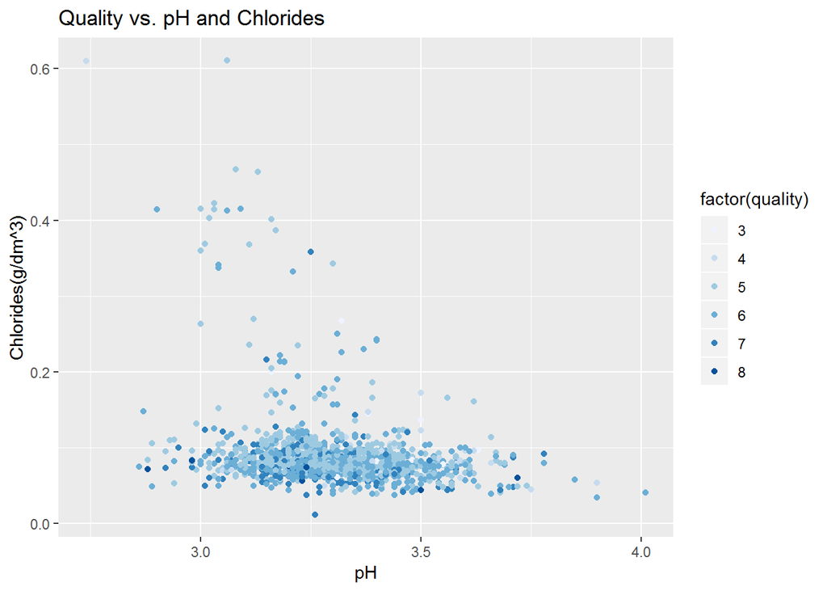

The graph represents the features influenced in the red wine quality, which are ph and Chlorides. It shows that these features do not have obvious influence in the quality of red wine except in the lower range of Chlorides and the range between (3.0 and 3.5 g/dm^3) of pH.